# ford_go_bike

## Ford go Bike

this will be an analysis and visualization report for ford go bike trip data which is a bike rental company we have data for more than 500,000 trips the data include variables like bike id, user type, start station and stations locations via longitude and lattitude and also thier sation id's.

### Project walkthrough:

I will start by exploring he data in general and trying to find any interesting observations the I will pose interesting questions and try to answer them using visuals and maybe other means.

### General Exploration:

```python
#imports
import pandas as pd
import matplotlib.pyplot as plt
import seaborn as sb
import numpy as np
#reading the data into a pandas data frame called df
df = pd.read_csv(r'2017-fordgobike-tripdata.csv')
```

```python
#exploring the data with pandas
df.head()
```

|  | duration_sec | start_time | end_time | start_station_id | start_station_name | start_station_latitude | start_station_longitude | end_station_id | end_station_name | end_station_latitude | end_station_longitude | bike_id | user_type |
| --- | --- | --- | --- | --- | --- | --- | --- | --- | --- | --- | --- | --- | --- |
| 0 | 80110 | 2017-12-31 16:57:39.6540 | 2018-01-01 15:12:50.2450 | 74 | Laguna St at Hayes St | 37.776435 | -122.426244 | 43 | San Francisco Public Library (Grove St at Hyde... | 37.778768 | -122.415929 | 96 | Customer |
| 1 | 78800 | 2017-12-31 15:56:34.8420 | 2018-01-01 13:49:55.6170 | 284 | Yerba Buena Center for the Arts (Howard St at ... | 37.784872 | -122.400876 | 96 | Dolores St at 15th St | 37.766210 | -122.426614 | 88 | Customer |
| 2 | 45768 | 2017-12-31 22:45:48.4110 | 2018-01-01 11:28:36.8830 | 245 | Downtown Berkeley BART | 37.870348 | -122.267764 | 245 | Downtown Berkeley BART | 37.870348 | -122.267764 | 1094 | Customer |
| 3 | 62172 | 2017-12-31 17:31:10.6360 | 2018-01-01 10:47:23.5310 | 60 | 8th St at Ringold St | 37.774520 | -122.409449 | 5 | Powell St BART Station (Market St at 5th St) | 37.783899 | -122.408445 | 2831 | Customer |
| 4 | 43603 | 2017-12-31 14:23:14.0010 | 2018-01-01 02:29:57.5710 | 239 | Bancroft Way at Telegraph Ave | 37.868813 | -122.258764 | 247 | Fulton St at Bancroft Way | 37.867789 | -122.265896 | 3167 | Subscriber |

```python
df.shape
```

```
(519700, 13)
```

```python
df.describe()
```

|  | duration_sec | start_station_id | start_station_latitude | start_station_longitude | end_station_id | end_station_latitude | end_station_longitude | bike_id |
| --- | --- | --- | --- | --- | --- | --- | --- | --- |
| count | 519700.000000 | 519700.000000 | 519700.000000 | 519700.000000 | 519700.000000 | 519700.000000 | 519700.000000 | 519700.000000 |
| mean | 1099.009521 | 95.034245 | 37.771653 | -122.363927 | 92.184041 | 37.771844 | -122.363236 | 1672.533079 |
| std | 3444.146451 | 86.083078 | 0.086305 | 0.105573 | 84.969491 | 0.086224 | 0.105122 | 971.356959 |
| min | 61.000000 | 3.000000 | 37.317298 | -122.444293 | 3.000000 | 37.317298 | -122.444293 | 10.000000 |
| 25% | 382.000000 | 24.000000 | 37.773492 | -122.411726 | 23.000000 | 37.774520 | -122.410345 | 787.000000 |
| 50% | 596.000000 | 67.000000 | 37.783521 | -122.398870 | 66.000000 | 37.783830 | -122.398525 | 1728.500000 |
| 75% | 938.000000 | 139.000000 | 37.795392 | -122.391034 | 134.000000 | 37.795392 | -122.391034 | 2520.000000 |
| max | 86369.000000 | 340.000000 | 37.880222 | -121.874119 | 340.000000 | 37.880222 | -121.874119 | 3733.000000 |

```python
df.info()
```

```
<class 'pandas.core.frame.DataFrame'>
RangeIndex: 519700 entries, 0 to 519699
Data columns (total 13 columns):
 #   Column                   Non-Null Count   Dtype
---  ------                   --------------   -----
 0   duration_sec             519700 non-null  int64
 1   start_time               519700 non-null  object
 2   end_time                 519700 non-null  object
 3   start_station_id         519700 non-null  int64
 4   start_station_name       519700 non-null  object
 5   start_station_latitude   519700 non-null  float64
 6   start_station_longitude  519700 non-null  float64
 7   end_station_id           519700 non-null  int64
 8   end_station_name         519700 non-null  object
 9   end_station_latitude     519700 non-null  float64
 10  end_station_longitude    519700 non-null  float64
 11  bike_id                  519700 non-null  int64
 12  user_type                519700 non-null  object
dtypes: float64(4), int64(4), object(5)
memory usage: 51.5+ MB
```

#### Notes and observations:

We have clean data that has no nulls and the data description has no anomalys or weird number that stand out to me that's why inorder to further explore the data we need to do it visualy.

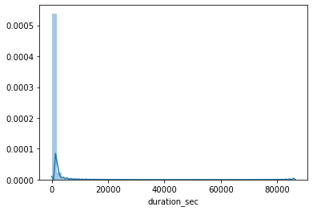

```python
#univariate exploration of duration in seconds
sb.distplot(df.duration_sec);
```

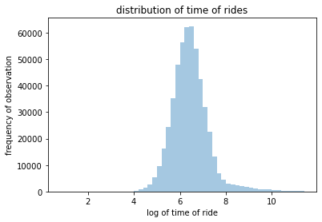

```python
#plotting the log of duration in seconds and visualising it to see if it gives further insight

bins = np.arange(0.8, np.log(df['duration_sec']).max()+ 0.2, 0.2 )
sb.distplot(np.log(df.duration_sec), kde = False, bins = bins);
plt.title('distribution of time of rides');
plt.xlabel('log of time of ride')
plt.ylabel('frequency of observation')
```

So it's ovious that the most of the trips have duration between 0-30 minutes which makes sense any longer and people might want to get a cab in most cases where they are renting it for commute and not sport.

an interesting question came to mind is to find the high traffic times where alot of bikes are being used during the day in order to anticipate any shortages and thats what I will be exploring next.

```python
#creating an hour column to identify at what hour does the trip start
df['start_time'] = pd.to_datetime(df['start_time'])
df['time_hour'] = df['start_time'].apply(lambda x: x.hour)
```

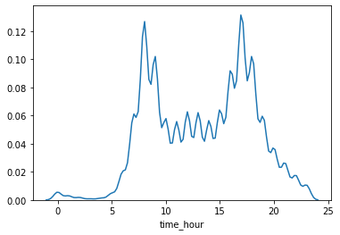

```python
#plotting the hours of day in which trips appear most frequently
sb.distplot(df['time_hour'], hist = False);
```

the ditribution has two peaks through out the day the first one is around 8 am where people are likely going to work or school and the second is at 5 pm where people are likely getting off from work and school this indicates that our customers are likely working adults and we should target our marketing campaigns at the places where we are more likley to find them for example in offices or universities around the city. ALso the distribution fades out after dark I would check to see if the bikes have lights or night visuals inorder to be vivsible and more people will deem them safe to ride at night.

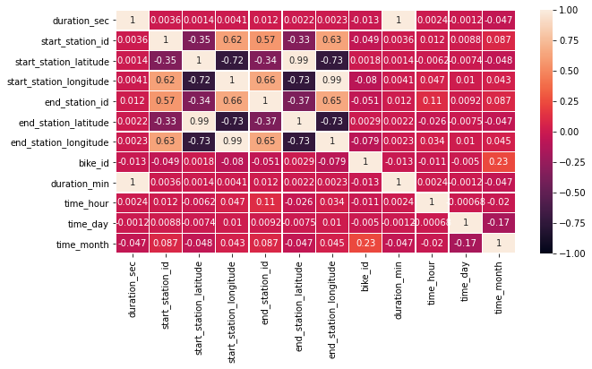

```python
figure = plt.figure(figsize= (10,5))
ax = sb.heatmap(df.corr(), linewidths=0.5, vmin = -1, vmax = 1, annot = True, fmt = '.2g');
```

the high correllations between longitude and latitudes of start and end sations is due to the tendensy of people to return the bikes to a close station from where they strated there trip and the closeness of the stations to each other.

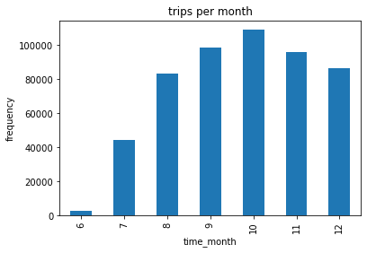

```python
#plottin months to number of trips
df.groupby('time_month')['time_month'].count().plot(kind = 'bar', title = 'trips per month');
plt.ylabel('frequency');
```

in this plot we can see that june is the lowest month for trips and october was the highest perhaps it's beacause more and more people got used to the idea of cycling with the bikes and adapted this into their routines.

```python
#creating a column just for the date
df['start_date'] = df['start_time'].apply(lambda x :x.date())
```

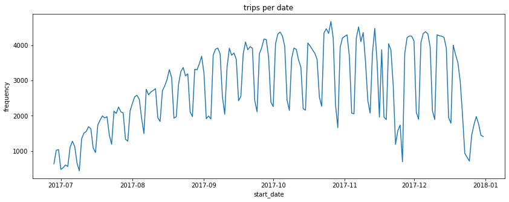

```python
#plotting the data with regards to dates
df.groupby('start_date')['start_date'].count().plot(kind = 'line', title = 'trips per date', figsize = (14,5));
plt.ylabel('frequency');
```

the data shows the same monthly trends with 4 falls each month suggesting that the weekends are not as popular as work days further instilling the idea that people use the bikes to commute to and from work.

```python
#creating a data frame to be able to plot the geographic data
df2 = pd.DataFrame()
df2['longitudes'] = df.start_station_longitude.unique()
df2['latitudes'] = df.start_station_latitude.unique()
df2['label'] = df.start_station_name.unique()
```

```python
#further feature engineering
frequency = []
for i in df.start_station_name.unique():
    num = df[df.start_station_name == i].shape[0]
    frequency.append(num)
```

```python
#creating the frequency column to see the amiunt of times the bikes have been taken from each station
frequency = np.array(frequency)
df2['frequency'] = frequency
df2.head()
```

|  | longitudes | latitudes | label | frequency |
| --- | --- | --- | --- | --- |
| 0 | -122.426244 | 37.776435 | Laguna St at Hayes St | 2731 |
| 1 | -122.400876 | 37.784872 | Yerba Buena Center for the Arts (Howard St at ... | 2249 |
| 2 | -122.267764 | 37.870348 | Downtown Berkeley BART | 1667 |
| 3 | -122.409449 | 37.774520 | 8th St at Ringold St | 2571 |
| 4 | -122.258764 | 37.868813 | Bancroft Way at Telegraph Ave | 1474 |

```python
#import package for geoplotting
import folium
```

```python
#creating the geographical map
m = folium.Map(location=[df2.latitudes.mean(), df2.longitudes.mean()], zoom_start=10)

marker_cluster = MarkerCluster().add_to(m)

for lat, lng, label in zip(df2.latitudes, df2.longitudes, df2.label):
    folium.Marker([lat, lng], radius=5, popup=label, fill=True,color='Blue', fill_color='Yellow', fill_opacity=0.6).add_to(marker_cluster)
```

```python
#viewing the map
m
```

Make this Notebook Trusted to load map: File -> Trust Notebook

[interactive chart not shown]

the maps show that the stations are concentrated in three main areas which are San Francisco, San Jose and Berkley. and these are the 272 stations in the data set they have all been used as start and end stations.

what is the main differences in trips for user types so i'll be doing the analysis but inspecting another variable which is user types

```python
#seperating customers from subscribers to be able to plot them
customers = df.query('user_type == "Customer"')
subscribers = df.query('user_type == "Subscriber"')
```

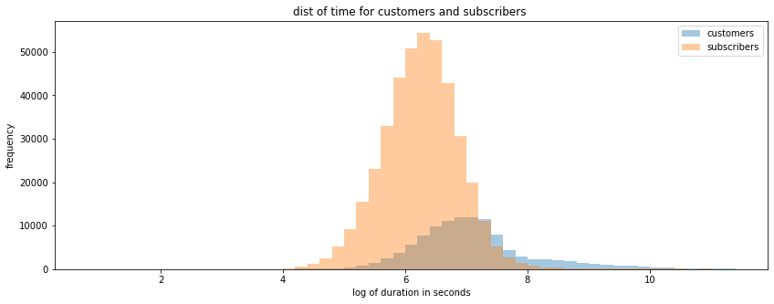

```python
#plotting to distributions one for customer ride times and one for subscriber ride times
plt.figure(figsize = (14,5))
bins = np.arange(0.8, np.log(df['duration_sec']).max()+ 0.2, 0.2 )

sb.distplot(np.log(customers.duration_sec), kde = False, bins = bins, label = 'customers');

sb.distplot(np.log(subscribers.duration_sec), kde = False, bins = bins, label = 'subscribers');
plt.legend();
plt.ylabel('frequency')
plt.xlabel('log of duration in seconds')
plt.title('dist of time for customers and subscribers ');
```

while there are many more subscriber rides than customer's the customers tend to spend more time on the bike each ride while the subscribers make more trips in general I presume, since there is no way of telling given this data how many customers and subcribers there are.

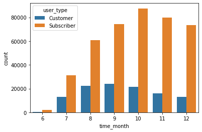

```python
#trips per month for different user types
sb.countplot(df.time_month, hue = df.user_type);
```

as the months go by the ratio off subscribers to customers is increasing suggesting that more customers are joining the subscribtion plan more and more people started to adopt the habit of riding the bikes hence the increase in the first few in the last two months the trips decrease and that could be due to it being the holiday season in the USA.

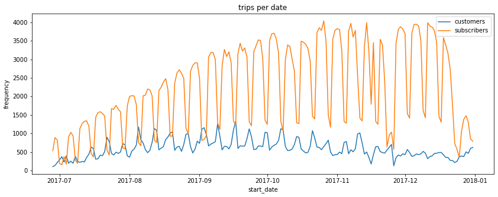

```python
#plotting the data with regards to dates
customers.groupby('start_date')['start_date'].count().plot(kind = 'line', title = 'trips per date', figsize = (14,5), label = 'customers');
subscribers.groupby('start_date')['start_date'].count().plot(kind = 'line', title = 'trips per date', figsize = (14,5), label = 'subscribers');
plt.ylabel('frequency');
plt.legend();
```

## Conclusion:

in conclusion due to my marketing backround I will look at this data from a marketeers prespective, Ford go bike's suscribers we now know are mostly commuting to work or university suggesting that there age ranges are between 18 and 40, people are adapting the ford go bike into there daily work commute from the time series analysis we can see that customers are converting to subscribers so more plans for subscribtion need to target recreational users and the bikes themselves need to be checked for safety driving at night.